# 8 Multivariate

Colin Kuehl

July 20, 2026

Packages

```r
#install.packages("ggcorrplot")
library("ggcorrplot")
#install.packages("modelsummary")
library("modelsummary")
#install.packages("coefplot")
library("coefplot")

library(tidyverse)
```

Set your working directory and load the English Premier League data data(prem.Rdata). What is the unit of analysis?

## Explore the data:

```r
setwd("~/Dropbox/POLS 641/CMU Su26/cmucourse26/ClassCode/Day 9")
load("prem.RData")

table(epl$Season_End_Year)
```

```
##
## 2017 2018 2019 2020 2021 2022
##   20   20   20   20   20   20
```

```r
table(epl$Squad)
```

```
##
##         Arsenal     Aston Villa     Bournemouth       Brentford        Brighton
##               6               3               4               1               5
##         Burnley    Cardiff City         Chelsea  Crystal Palace         Everton
##               6               1               6               6               6
##          Fulham    Huddersfield       Hull City    Leeds United  Leicester City
##               2               2               1               2               6
##       Liverpool Manchester City  Manchester Utd   Middlesbrough   Newcastle Utd
##               6               6               6               1               5
##    Norwich City   Sheffield Utd     Southampton      Stoke City      Sunderland
##               2               2               6               2               1
##    Swansea City       Tottenham         Watford       West Brom        West Ham
##               2               6               5               3               6
##          Wolves
##               4
```

Warm-up: Get a feel for the data and the variables. Check out your favorite team(or the one with the funniest name) and provide some interesting basic descriptive statistics

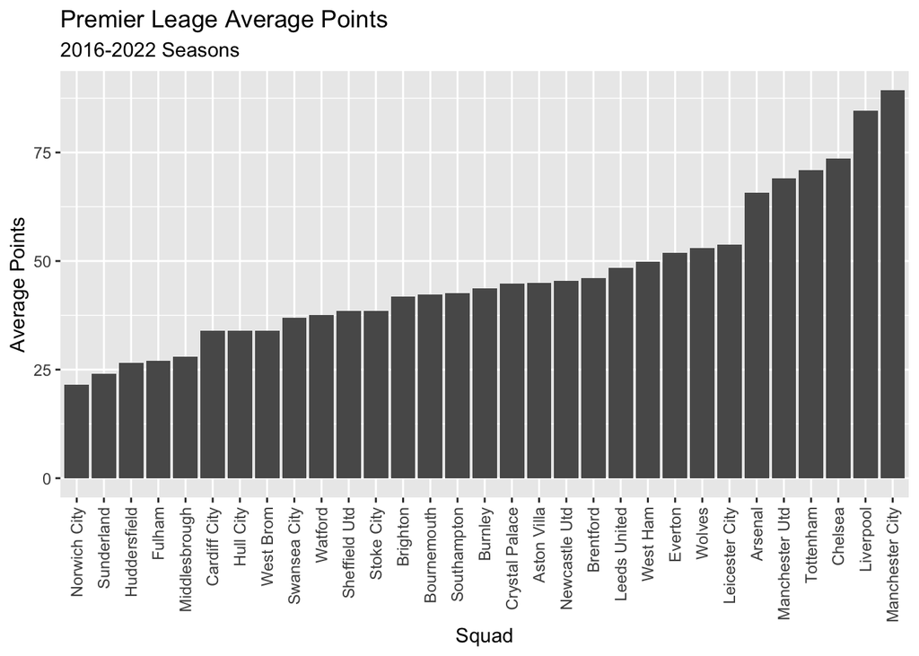

```r
cumultable <- epl %>% group_by(Squad)%>% summarise(avgwins=mean(W), avgpoints=mean(Pts))%>% arrange(avgpoints)

ggplot(data=cumultable, aes(x=fct_reorder(Squad, avgpoints), y=avgpoints))+geom_bar(stat="identity")+theme(axis.text.x = element_text(angle = 90, vjust = 0.5, hjust=1))+labs(x="Squad", y="Average Points", title="Premier Leage Average Points", subtitle = "2016-2022 Seasons")
```

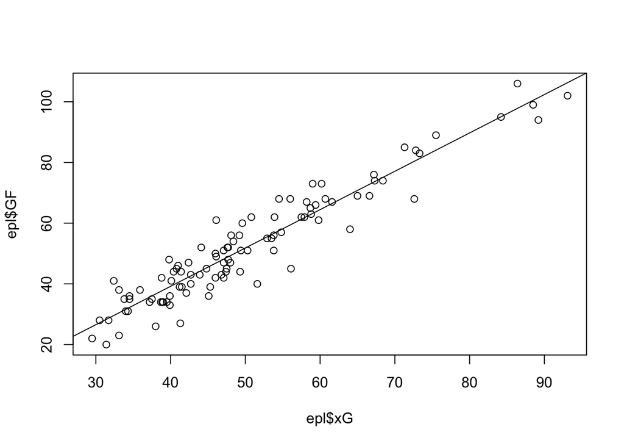

```r
plot(epl$xG, epl$GF)
abline(lm(epl$GF~epl$xG))
```

Look at correlation between variables of interet - Look at correlation matrix

```r
cor(epl$W, epl$GF)
```

```
## [1] 0.9396944
```

```r
cor(epl$W, epl$GA)
```

```
## [1] -0.8183202
```

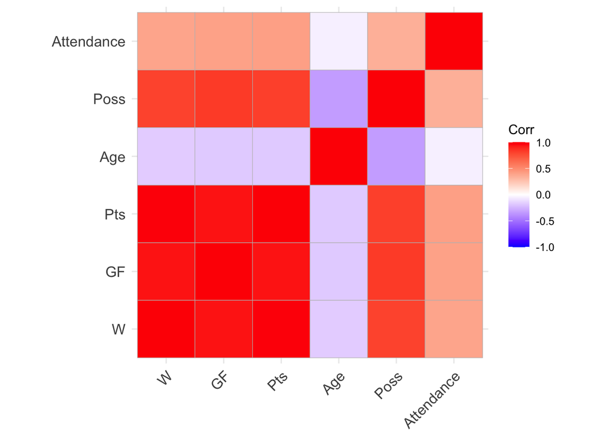

```r
mainvars  <- epl %>% select(W, GF, Pts, Age, Poss, Attendance)
cormat <- cor(mainvars)

ggcorrplot(cormat)#pretty graph, but I usually find the numbers more useful
```

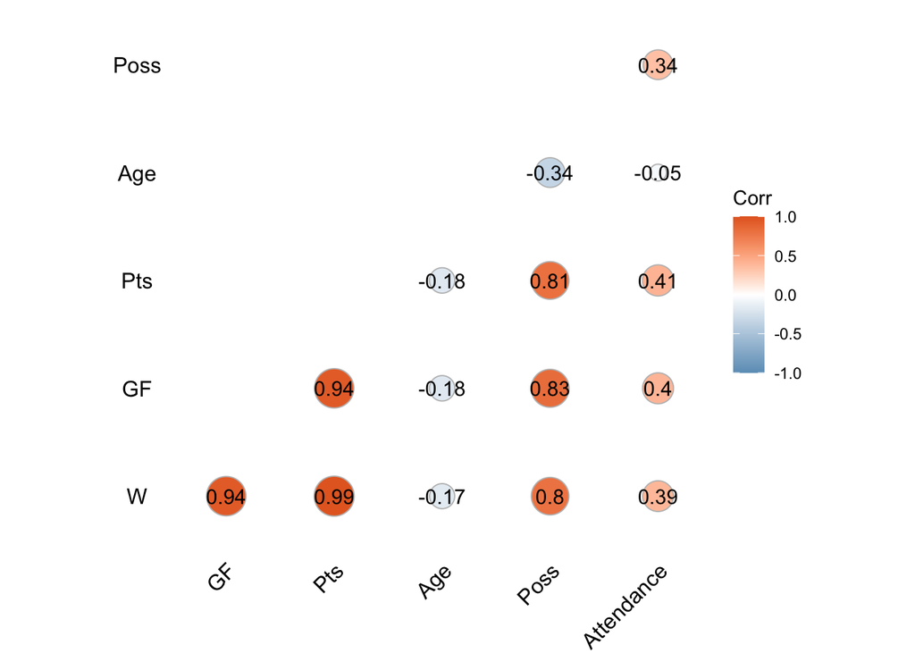

```r
ggcorrplot(cormat, lab=TRUE, method = "circle", type = "lower", ggtheme = theme_void(), colors = c("#6D9EC1", "white", "#E46726"))#looks cooler, but more useful?
```

```r
bi1 <- lm(Pts ~ xG, data=epl)
summary(bi1)
```

```
##
## Call:
## lm(formula = Pts ~ xG, data = epl)
##
## Residuals:
##      Min       1Q   Median       3Q      Max
## -22.2271  -5.7214   0.1823   5.9521  21.5125
##
## Coefficients:
##             Estimate Std. Error t value Pr(>|t|)
## (Intercept) -6.69761    3.22984  -2.074   0.0407 *
## xG           1.18072    0.06193  19.065   <2e-16 ***
## ---
## Signif. codes:  0 '***' 0.001 '**' 0.01 '*' 0.05 '.' 0.1 ' ' 1
##
## Residual standard error: 8.574 on 98 degrees of freedom
##   (20 observations deleted due to missingness)
## Multiple R-squared:  0.7876, Adjusted R-squared:  0.7855
## F-statistic: 363.5 on 1 and 98 DF,  p-value: < 2.2e-16
```

1. How do we interpret this output using text?
2. How do we show it graphically?
3. What is the equation? Hint: Use Rmarkdown Symbols

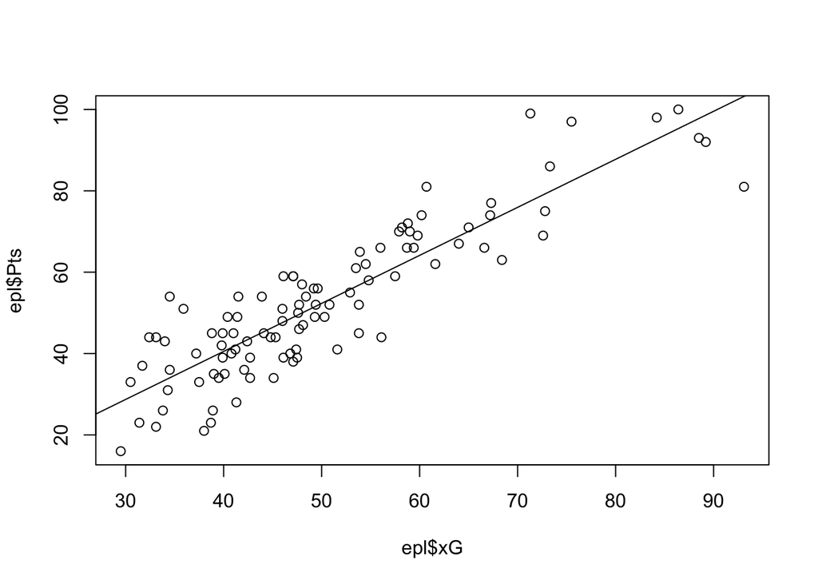

```r
# 2.
plot(epl$xG, epl$Pts)
abline(bi1)
```

3. $Y= \beta_{0} + Expected Goals X1 + \epsilon$ $Points= -6.69 + 1.18 X1 + \epsilon$

**Multivariate Regression** Multivariate OLS (Refers to OLS with multiple independent variables) What’s the benefit? Reduces biased + increases precision (more accurate parameter estimates), because the coefficient estimates are on average less skewed away from the true value. Ie we know there are other factors besides shooting that matter for winning teams. We are taking these things from the error term and putting them into the model.

When interpreting multivariate OLS regression coefficients: A one unit increase in X is associated with an increase in Y, HOLDING OTHER FACTORS CONSTANT IN THE MODEL/ceteris paribus (all else being equal) (Page 131-132)

4. Lets create a multivariate model: $Y= \beta_{0} + \beta_{1} X1 + \epsilon$

$Points = \beta_{0} + \beta_{1}expectedgoals + \beta_{2}possession + \epsilon$

```r
multi1 <- lm(Pts ~ xG + Poss, data=epl)
summary(multi1)
```

```
##
## Call:
## lm(formula = Pts ~ xG + Poss, data = epl)
##
## Residuals:
##      Min       1Q   Median       3Q      Max
## -20.5302  -4.6381  -0.1622   5.6527  20.3923
##
## Coefficients:
##             Estimate Std. Error t value Pr(>|t|)
## (Intercept) -16.3022     6.3501  -2.567   0.0118 *
## xG            0.9899     0.1251   7.914 4.08e-12 ***
## Poss          0.3838     0.2193   1.750   0.0832 .
## ---
## Signif. codes:  0 '***' 0.001 '**' 0.01 '*' 0.05 '.' 0.1 ' ' 1
##
## Residual standard error: 8.485 on 97 degrees of freedom
##   (20 observations deleted due to missingness)
## Multiple R-squared:  0.7941, Adjusted R-squared:  0.7899
## F-statistic: 187.1 on 2 and 97 DF,  p-value: < 2.2e-16
```

What is your DV? IVs? How do we interpret this table? How has the r-squared changed from the model1. Bonus: What is the points we would expect for a team that had an average(mean) xG and an average possession? (clue: first find the means and then input into your equation)

```r
multi2 <- lm(Pts ~ xG + Poss + Age, data=epl)
summary(multi2)
```

```
##
## Call:
## lm(formula = Pts ~ xG + Poss + Age, data = epl)
##
## Residuals:
##      Min       1Q   Median       3Q      Max
## -21.4238  -4.7666   0.2106   4.9125  19.7746
##
## Coefficients:
##             Estimate Std. Error t value Pr(>|t|)
## (Intercept) -60.9163    27.5759  -2.209   0.0296 *
## xG            0.9657     0.1248   7.738 1.01e-11 ***
## Poss          0.4817     0.2251   2.140   0.0349 *
## Age           1.5318     0.9218   1.662   0.0998 .
## ---
## Signif. codes:  0 '***' 0.001 '**' 0.01 '*' 0.05 '.' 0.1 ' ' 1
##
## Residual standard error: 8.409 on 96 degrees of freedom
##   (20 observations deleted due to missingness)
## Multiple R-squared:  0.7999, Adjusted R-squared:  0.7936
## F-statistic: 127.9 on 3 and 96 DF,  p-value: < 2.2e-16
```

6. Maybe the fans matter

```r
multi3 <- lm(Pts ~ xG + Poss + Age + Attendance, data=epl)
summary(multi3)
```

```
##
## Call:
## lm(formula = Pts ~ xG + Poss + Age + Attendance, data = epl)
##
## Residuals:
##      Min       1Q   Median       3Q      Max
## -20.3056  -4.7492  -0.3667   5.3940  19.6650
##
## Coefficients:
##               Estimate Std. Error t value Pr(>|t|)
## (Intercept) -5.912e+01  2.724e+01  -2.170   0.0325 *
## xG           9.309e-01  1.246e-01   7.471 3.86e-11 ***
## Poss         4.665e-01  2.224e-01   2.097   0.0386 *
## Age          1.469e+00  9.107e-01   1.613   0.1100
## Attendance   8.170e-05  4.367e-05   1.871   0.0645 .
## ---
## Signif. codes:  0 '***' 0.001 '**' 0.01 '*' 0.05 '.' 0.1 ' ' 1
##
## Residual standard error: 8.301 on 95 degrees of freedom
##   (20 observations deleted due to missingness)
## Multiple R-squared:  0.807,  Adjusted R-squared:  0.7989
## F-statistic: 99.31 on 4 and 95 DF,  p-value: < 2.2e-16
```

## Displaying Multiple Models

Useful tool: Displaying mulitple tables using model summary: More info

```r
#summary(multi1, multi2) doesn't work
#install.packages("modelsummary")
library("modelsummary")

modelsummary(list(multi1, multi2))
```

|  | (1) | (2) |
| --- | --- | --- |
| (Intercept) | -16.302 | -60.916 |
|  | (6.350) | (27.576) |
| xG | 0.990 | 0.966 |
|  | (0.125) | (0.125) |
| Poss | 0.384 | 0.482 |
|  | (0.219) | (0.225) |
| Age |  | 1.532 |
|  |  | (0.922) |
| Num.Obs. | 100 | 100 |
| R2 | 0.794 | 0.800 |
| R2 Adj. | 0.790 | 0.794 |
| AIC | 716.4 | 715.6 |
| BIC | 726.8 | 728.6 |
| Log.Lik. | -354.199 | -352.781 |
| RMSE | 8.36 | 8.24 |

```r
#copy and paste this output below. Will need to change labels etc.

modelsummary(list(bi1, multi1, multi2, multi3),
             title  = "Multivariate Regression Models")
```

Multivariate Regression Models

|  | (1) | (2) | (3) | (4) |
| --- | --- | --- | --- | --- |
| (Intercept) | -6.698 | -16.302 | -60.916 | -59.123 |
|  | (3.230) | (6.350) | (27.576) | (27.241) |
| xG | 1.181 | 0.990 | 0.966 | 0.931 |
|  | (0.062) | (0.125) | (0.125) | (0.125) |
| Poss |  | 0.384 | 0.482 | 0.466 |
|  |  | (0.219) | (0.225) | (0.222) |
| Age |  |  | 1.532 | 1.469 |
|  |  |  | (0.922) | (0.911) |
| Attendance |  |  |  | 0.000 |
|  |  |  |  | (0.000) |
| Num.Obs. | 100 | 100 | 100 | 100 |
| R2 | 0.788 | 0.794 | 0.800 | 0.807 |
| R2 Adj. | 0.785 | 0.790 | 0.794 | 0.799 |
| AIC | 717.5 | 716.4 | 715.6 | 713.9 |
| BIC | 725.3 | 726.8 | 728.6 | 729.6 |
| Log.Lik. | -355.754 | -354.199 | -352.781 | -350.972 |
| RMSE | 8.49 | 8.36 | 8.24 | 8.09 |

```r
modelsummary(list(bi1, multi1, multi2, multi3),
             title       = "Multivariate Regression Models (DV: Total Points)",
             coef_rename = c("xG"         = "Expected Goals",
                             "possession" = "Possession",
                             "age"        = "Age",
                             "attendance" = "Attendance",
                             "(Intercept)"= "Intercept"))
```

Multivariate Regression Models (DV: Total Points)

|  | (1) | (2) | (3) | (4) |
| --- | --- | --- | --- | --- |
| Intercept | -6.698 | -16.302 | -60.916 | -59.123 |
|  | (3.230) | (6.350) | (27.576) | (27.241) |
| Expected Goals | 1.181 | 0.990 | 0.966 | 0.931 |
|  | (0.062) | (0.125) | (0.125) | (0.125) |
| Poss |  | 0.384 | 0.482 | 0.466 |
|  |  | (0.219) | (0.225) | (0.222) |
| Age |  |  | 1.532 | 1.469 |
|  |  |  | (0.922) | (0.911) |
| Attendance |  |  |  | 0.000 |
|  |  |  |  | (0.000) |
| Num.Obs. | 100 | 100 | 100 | 100 |
| R2 | 0.788 | 0.794 | 0.800 | 0.807 |
| R2 Adj. | 0.785 | 0.790 | 0.794 | 0.799 |
| AIC | 717.5 | 716.4 | 715.6 | 713.9 |
| BIC | 725.3 | 726.8 | 728.6 | 729.6 |
| Log.Lik. | -355.754 | -354.199 | -352.781 | -350.972 |
| RMSE | 8.49 | 8.36 | 8.24 | 8.09 |

## Coefficient Plots

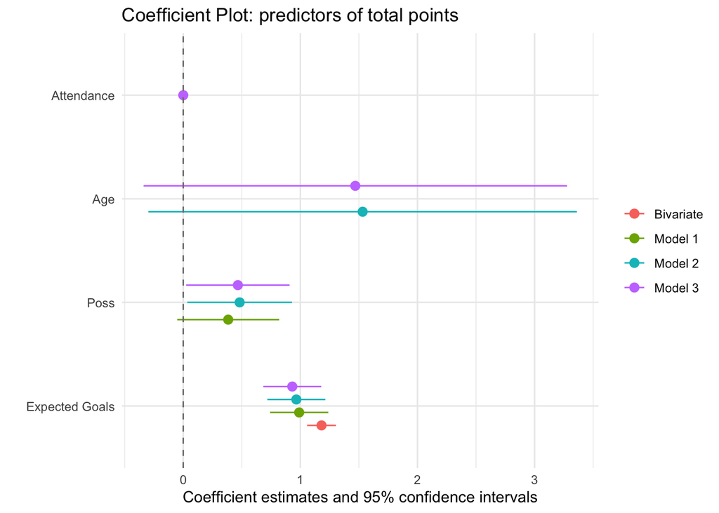

```r
modelplot(list("Bivariate" = bi1,
               "Model 1"   = multi1,
               "Model 2"   = multi2,
               "Model 3"   = multi3),
          coef_omit   = "Intercept",
          coef_rename = c("xG"         = "Expected Goals",
                          "possession" = "Possession",
                          "age"        = "Age",
                          "attendance" = "Attendance")) +
  ggplot2::geom_vline(xintercept = 0, linetype = "dashed", color = "grey50") +
  ggplot2::labs(title = "Coefficient Plot: predictors of total points")
```

## Adding Spending

That is all great, but we know sports is all about the benjamins(aka money). I want to know how much money predicts squad success but it isn’t in this dataset.

```r
wages <- read.csv("wages.csv") #Load wages data(from: https://www.spotrac.com/epl/payroll/2019/)

#as always there are a couple ways we can merge the data. Note we are just looking at one year now. We will have more examples of merging in a few weeks, but this gives you the basic idea.

#classic is the merge command. There must be a common column(same units with same exact lable/number etc) between both datasets. In this case that variable is named different things.
ep2020 <- epl[which(epl$Season_End_Year==2020),] #just look at 2020 season

epl2 <- merge(ep2020, wages, by.x="Squad", by.y="TEAM")
#dplyr uses join commands to do the same thing
epl2d <- left_join(epl, wages, by = c("Squad" = "TEAM"))

#This is about as simple as a merge/join command gets.
```

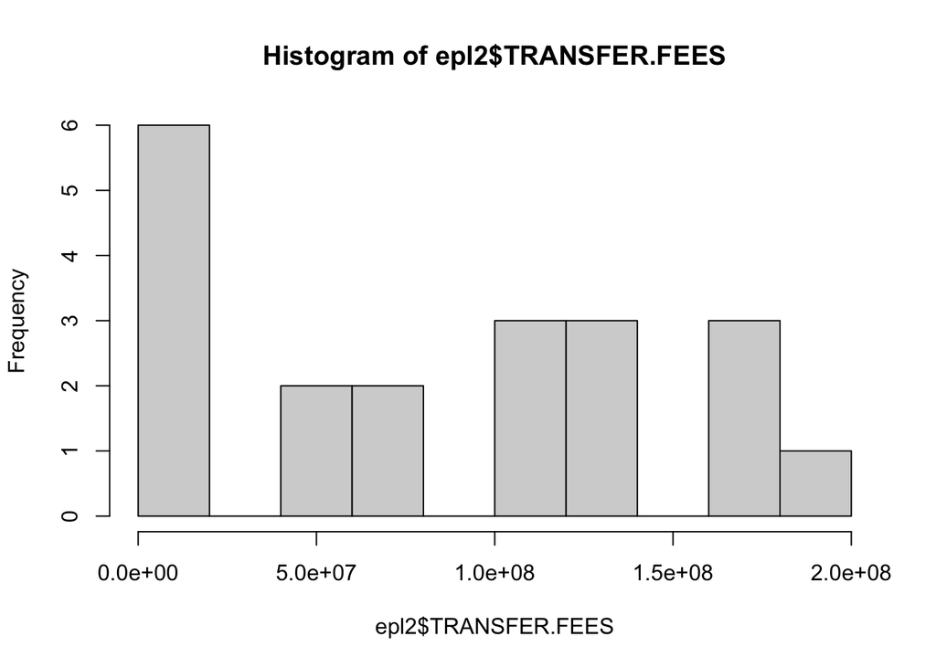

```r
hist(epl2$TRANSFER.FEES, breaks=8)
```

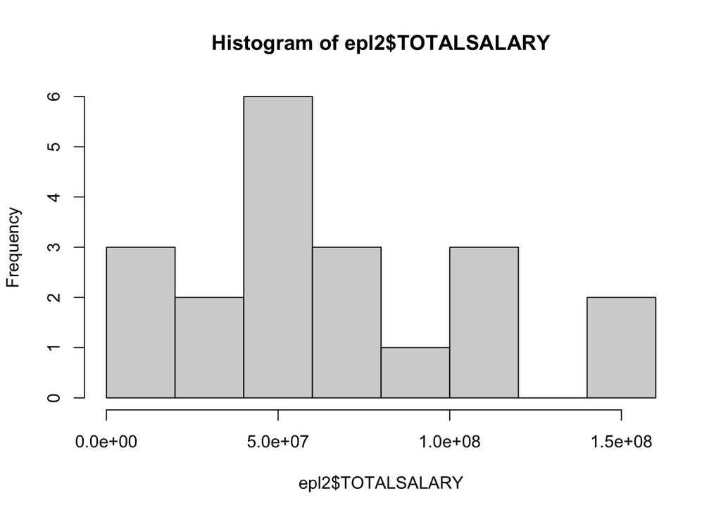

```r
hist(epl2$TOTALSALARY)
```

```r
cor(epl2$TRANSFER.FEES, epl2$TOTALSALARY)
```

```
## [1] 0.4539751
```

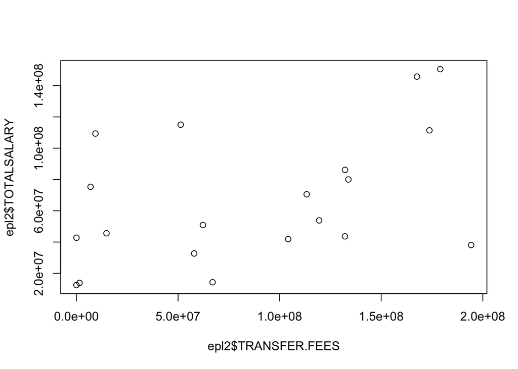

```r
plot(epl2$TRANSFER.FEES, epl2$TOTALSALARY)
```

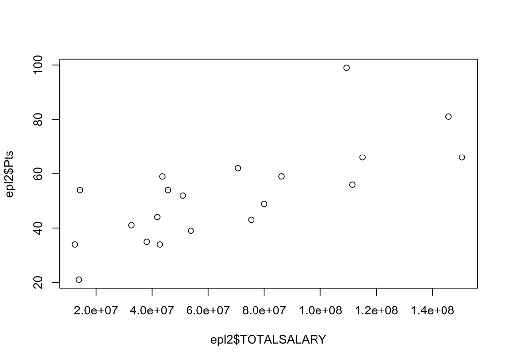

```r
plot(epl2$TOTALSALARY, epl2$Pts)
```

```r
bivariate <- (lm(Pts ~ TOTALSALARY, data=epl2))
```

```r
Model1 <- (lm(Pts ~ TOTALSALARY+TRANSFER.FEES, data=epl2))

Model2 <- (lm(Pts ~ TOTALSALARY+TRANSFER.FEES + xG+ Age + Attendance, data=epl2))

modelsummary(list(bivariate, Model1, Model2),
             title  = "Multivariate Regression Models")
```

Multivariate Regression Models

|  | (1) | (2) | (3) |
| --- | --- | --- | --- |
| (Intercept) | 31.557 | 33.047 | -27.097 |
|  | (5.327) | (5.665) | (71.682) |
| TOTALSALARY | 0.000 | 0.000 | 0.000 |
|  | (0.000) | (0.000) | (0.000) |
| TRANSFER.FEES |  | -0.000 | -0.000 |
|  |  | (0.000) | (0.000) |
| xG |  |  | 0.812 |
|  |  |  | (0.293) |
| Age |  |  | 0.975 |
|  |  |  | (2.477) |
| Attendance |  |  | 0.001 |
|  |  |  | (0.000) |
| Num.Obs. | 20 | 20 | 20 |
| R2 | 0.539 | 0.557 | 0.716 |
| R2 Adj. | 0.513 | 0.504 | 0.615 |
| AIC | 161.4 | 162.6 | 159.7 |
| BIC | 164.4 | 166.6 | 166.6 |
| Log.Lik. | -77.687 | -77.289 | -72.827 |
| RMSE | 11.77 | 11.54 | 9.23 |

Some fun visualizations

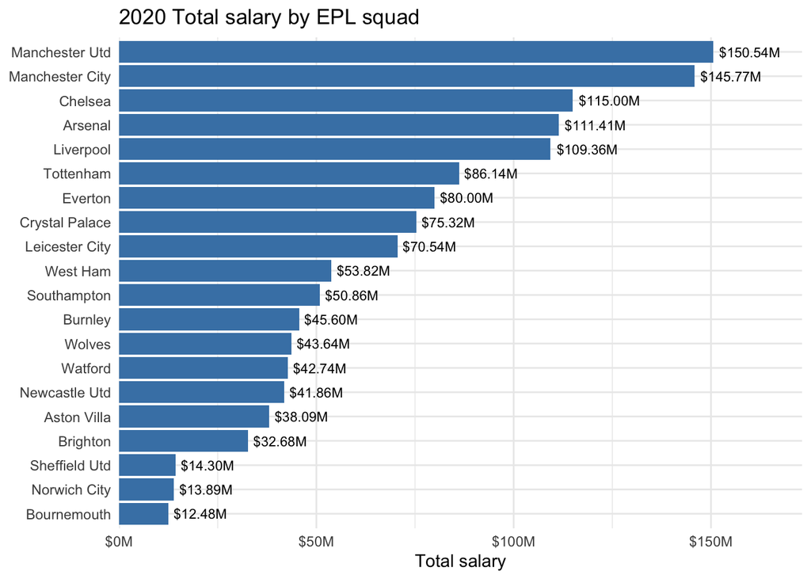

```r
ggplot(epl2, aes(x = reorder(Squad, TOTALSALARY), y = TOTALSALARY)) +
  geom_col(fill = "steelblue") +
  geom_text(aes(label = scales::dollar(TOTALSALARY, scale = 1e-6, suffix = "M")), #Fancy rescaling
            hjust = -0.1, size = 3) +
  scale_y_continuous(labels = scales::dollar_format(scale = 1e-6, suffix = "M"),
                     expand = expansion(mult = c(0, 0.15))) +
  coord_flip() +
  labs(title = "2020 Total salary by EPL squad",
       x = NULL, y = "Total salary") +
  theme_minimal()
```

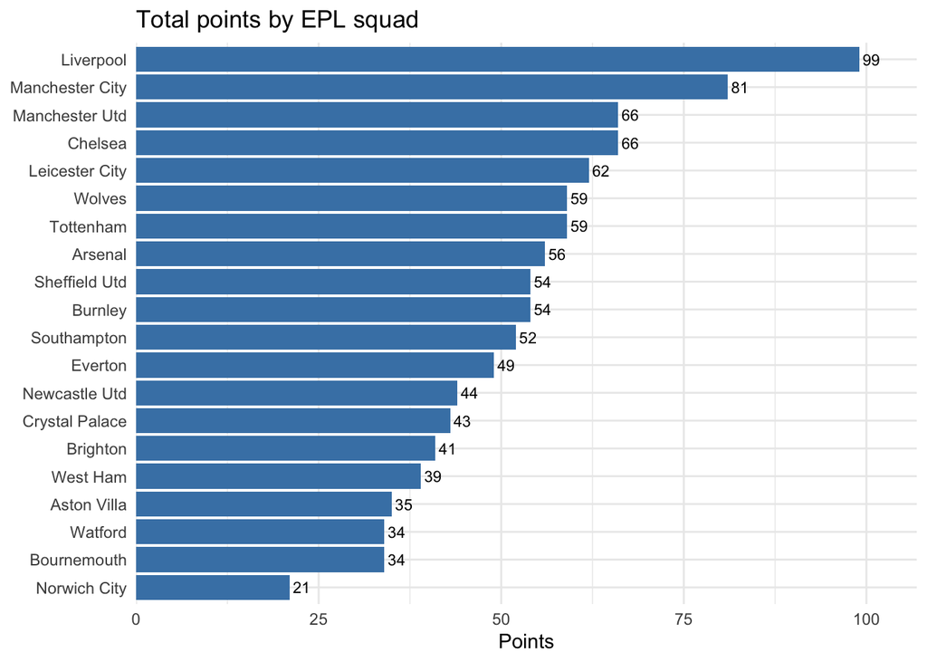

```r
ggplot(epl2, aes(x = reorder(Squad, Pts), y = Pts)) +
  geom_col(fill = "steelblue") +
  geom_text(aes(label = Pts), hjust = -0.2, size = 3) +
  scale_y_continuous(expand = expansion(mult = c(0, 0.08))) +
  coord_flip() +
  labs(title = "Total points by EPL squad",
       x = NULL, y = "Points") +
  theme_minimal()
```

## Create Multiple Models

Your turn. With this new create additional models

### Extra code for R nerds:

Creates a 3d scatterplot of our variables. Ie shows two independent variables and a dependent variable.

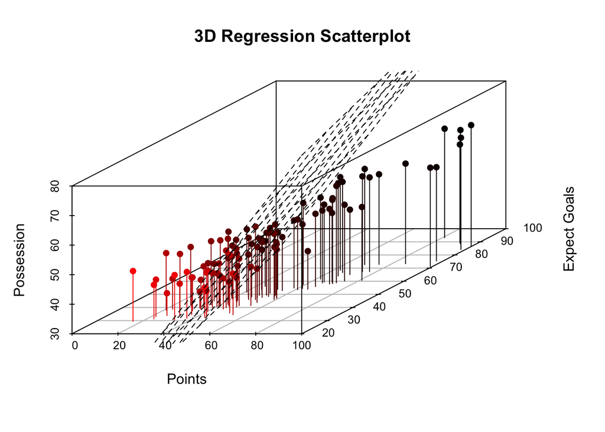

```r
#install.packages("scatterplot3d")
library(scatterplot3d)
s3d <-scatterplot3d(epl$Pts, epl$xG,  epl$Poss,
                    pch=16, highlight.3d=TRUE,
type="h", main="3D Regression Scatterplot", xlab="Points", ylab="Expect Goals", zlab="Possession")
s3d$plane3d(multi1)
```

Bonus: Create multiple models. Is the coefficient for xG robust?

Bonus 2: Is points really the best measure of how well a team has done? Try alternative DVs